# Upf1-associated targets in Cryptococcus deneoformans

Edward Wallace, ewjwallace@gmail.com

22 Mar 2019

# Summary

Analysis of the DESeq2 results for Upf1 vs WT of Cryptococcus deneoformans JEC21.

## Load data

### Plot densities of read counts

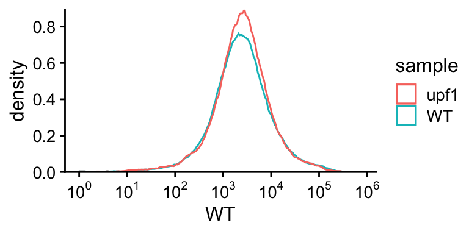

# Differential gene expression

## Volcano plot of differential gene expression

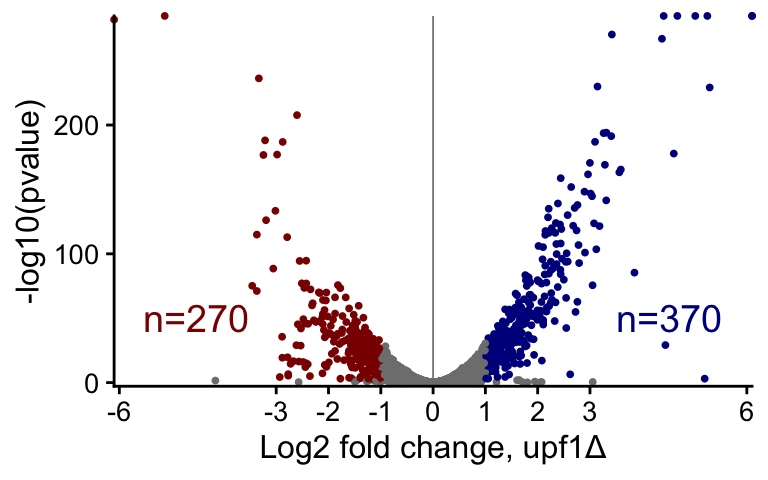

## Genes up in WT vs upf1 (this is not meant to be the interesting bit)

```
## # A tibble: 6,634 x 5
##    Gene        WT upf1E30 log2FoldChange    pvalue
##    <chr>    <dbl>   <dbl>          <dbl>     <dbl>
##  1 CNC02960  3466      21          -7.36 1.31e-282
##  2 CNE00400 18228     517          -5.13 0.
##  3 CNE00100     3       0          -4.16 2.70e-  2
##  4 CNI00990  2356     213          -3.46 7.13e- 76
##  5 CNN02180   550      52          -3.37 7.61e- 72
##  6 CNN01595  6536     632          -3.37 1.24e-115
##  7 CNA00820  8444     839          -3.33 5.84e-237
##  8 CNF04420 14751    1556          -3.24 1.79e-177
##  9 CNJ03160 46857    5052          -3.21 8.00e-189
## 10 CNC04900  3321     362          -3.19 7.82e-127
## # … with 6,624 more rows
```

CNC02960 is upf1, the deleted gene. Others don’t make sense.

### with minimal expression filter

```
## # A tibble: 1,760 x 5
##    Gene        WT upf1E30 log2FoldChange    pvalue
##    <chr>    <dbl>   <dbl>          <dbl>     <dbl>
##  1 CNJ03160 46857    5052          -3.21 8.00e-189
##  2 CNG00370 45941    6644          -2.79 1.18e-113
##  3 CNG04220 54610    8261          -2.72 2.67e- 15
##  4 CNG04230 42921    7877          -2.45 1.60e- 46
##  5 CNA05600 44332    8730          -2.34 4.16e- 73
##  6 CNE04080 89534   17995          -2.32 1.12e- 60
##  7 CND01230 25105    5785          -2.12 1.52e- 51
##  8 CNC00310 25313    5844          -2.12 6.49e-  8
##  9 CNI02990 23009    5412          -2.09 1.58e- 41
## 10 CNC05950 21312    5054          -2.08 4.84e- 57
## # … with 1,750 more rows
```

Several genes that expressed more highly in the presence of upf1 are expressed evne more highly (or at least escpae the general repression) in stationary phase cells. This suggests that some upf1-linked mechanism might repress them in fast growth and is turned off in stat phase, e.g. missing co-factor.

- CNJ03160/CNAG_04891, JEC21 homolog repressed by heat, H99 homolog has low expression in YPD, way up in RPMI. Doesn’t make sense.
- CNG00370/CNAG_03566 maybe interesting, has a uORF (but wrong direction), up in stat and RPMI/macrophages
- CNG04220/CNAG_03143 HSP12, also up in stat & RPMI
- CNG04230/CNAG_03142, unknown, divergent w/ HSP12, also up in stat & RPMI
- CNA05600/CNAG_00575, catalase CAT3, also up in stat & RPMI
- CNE04080/CNAG_02129, unknown, repressed by heat, up in stat phase & RPMI
- CND01230/CNAG_00995, Msc1 homolog, up in stat phase
- CNC00310/CNAG_03058, Hmp1, repressed by heat in exp phase, up in stat phase & RPMI
- CNI02990/CNAG_04163, unknown mucin/flocculin, repressed by heat in exp phase
- CNC05950/CNAG_02986 YSA1 ADP-ribose diphosphatase, repressed by heat in exp. phase

## Genes down in WT vs upf1 (NMDcandidates)

```
## # A tibble: 6,634 x 5
##    Gene        WT upf1E30 log2FoldChange    pvalue
##    <chr>    <dbl>   <dbl>          <dbl>     <dbl>
##  1 CNC01660    79   90595          10.2  0.
##  2 CNH03500    57   50264           9.78 0.
##  3 CNK00860    90    3611           5.29 7.02e-230
##  4 CNG03340   772   29197           5.24 0.
##  5 CND00010     0       7           5.19 8.69e-  4
##  6 CNG00950   156    5032           5.01 0.
##  7 CNH03490  1030   26268           4.67 0.
##  8 CNB01570    69    1647           4.60 1.46e-178
##  9 CNL06410   822   17887           4.44 7.32e- 30
## 10 CNC06440  3487   74142           4.41 0.
## # … with 6,624 more rows
```

- CNC01660/CNAG_01653 CIG1, H99 high expression in macrophages, otherwise low.
- CNH03500/CNAG_05278 is unkown prot, no proteomics, barely detected except in upf1KO. Maybe an unstable tx?
- CNC06440/CNAG_01539 inositol-3-phosphate synthase INO1, clear uORF w/occupancy

These make little sense collectively

### with minimal expression filter

```
## # A tibble: 1,747 x 5
##    Gene        WT upf1E30 log2FoldChange    pvalue
##    <chr>    <dbl>   <dbl>          <dbl>     <dbl>
##  1 CNF00330 18281  215834           3.56 5.10e-164
##  2 CNG04240 14882  127282           3.10 1.10e-187
##  3 CNA04360 26074  134144           2.36 1.65e-100
##  4 CND01050  6799   32780           2.27 1.18e-120
##  5 CNM00970  6183   19272           1.64 4.49e- 63
##  6 CNC02150 16781   43626           1.38 1.33e- 57
##  7 CNC01160  6472   15456           1.26 6.59e- 43
##  8 CNC03630  5088   11749           1.21 9.24e- 31
##  9 CNJ00080  6998   15338           1.13 7.11e- 26
## 10 CND01910 19334   39900           1.04 5.88e- 19
## # … with 1,737 more rows
```

Of the top *7/10* have clear uORFs with ribosomal occupancy. This is a very clear link.

- CNF00330/CNAG_07695 is the putative GABA transporter with crazy 5’ structure including uORF!
- CNG04240/CNAG_03140 is the putative sugar transporter with six uORFs!
- CNA04360/CNAG_00456 identified spore protein isp6, no uORF
- CND01050/CNAG_00976 carbamoyl-phosphate synthase, uORF w/occupancy
- CNM00970/CNAG_06090 clearly uORF w/occupancy
- CNC02150/CNAG_01709 translation factor eIF5, uORF w/occupancy
- CNC01160/CNAG_01603 hypothetical protein, uORF w/ ridiculous occupancy
- CNC03630/CNAG_02738 maybe 2-dehydropantoate 2-reductase, no uORF
- CNJ00080/CNAG_07865 ferroxidase Fet3/5, uORF w/occupancy
- CND01910/CNAG_01060 SR-like RNA-binding protein homologous to splicing regulators, intron near 5’ end of ORF partially retained with in-frame stop codon (CNAG_00260 & CNAG_00399 also homologs)

### Other genes of interest

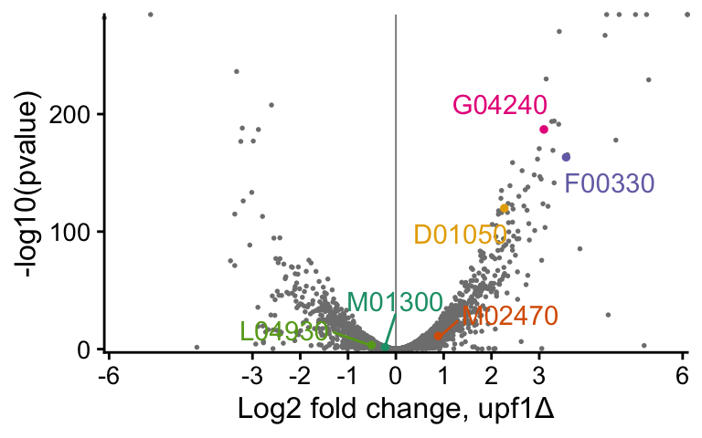

```
## # A tibble: 7 x 5
##   Gene         WT upf1E30 log2FoldChange    pvalue
##   <chr>     <dbl>   <dbl>          <dbl>     <dbl>
## 1 CNF00330  18281  215834          3.56  5.10e-164
## 2 CNG04240  14882  127282          3.10  1.10e-187
## 3 CND01050   6799   32780          2.27  1.18e-120
## 4 CNM02470  44438   82049          0.885 6.49e- 12
## 5 CNB05380  19617   22815          0.218 4.09e-  2
## 6 CNM01300 600594  514171         -0.224 2.20e-  2
## 7 CNL04930   9334    6556         -0.51  3.53e-  4
```

## Output gene lists

Genes_up_deltaUpf1_vs_JEC21.txt

Genes_down_deltaUpf1_vs_JEC21.txt

I also used PANTHERdb to do GO analysis on these lists. The results were mostly not interesting.

Except, Genes_down_deltaUpf1_vs_JEC21 was 2.3x enriched for genes wich MF Oxidoreductase activity (GO:0016491). This includes alternative oxidase, many dehydrogenases, etc. That looks interesting. These genes in pantherGeneList_deltaUpf1_up_oxidoreductase_GO0016491.txt

# Connect Diff Exp to uAUG count

## Volcano plot of differential gene expression

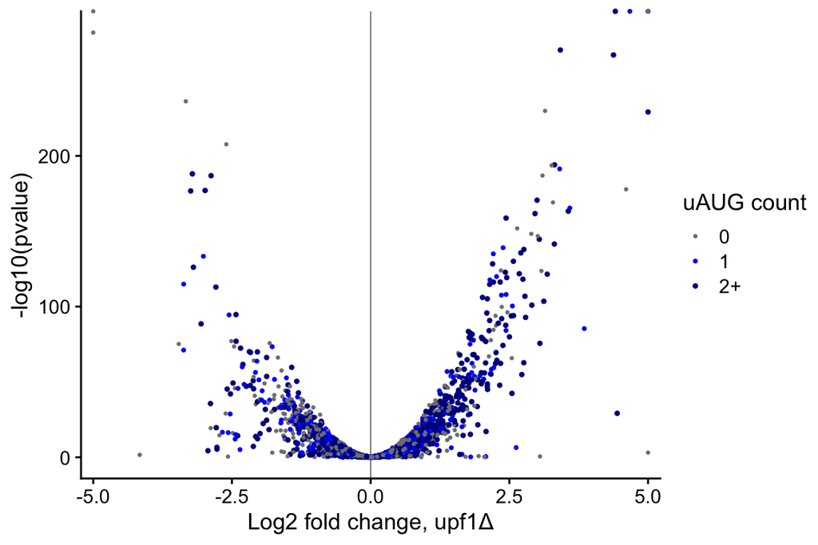

## Fold Change vs uATG count

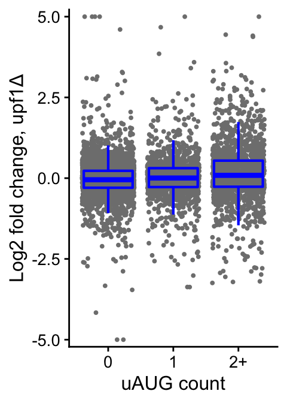

## Fold Change vs uATG count, ecdf

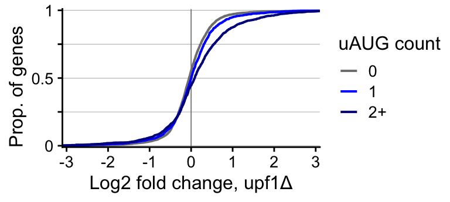

## Fold Change vs uATG count, KS test

```
##
##  Two-sample Kolmogorov-Smirnov test
##
## data:  udiff %>% filter(uATGCtC == "0") %>% .$log2FoldChange and udiff %>% filter(uATGCtC == "1") %>% .$log2FoldChange
## D^+ = 0.069339, p-value = 5.731e-05
## alternative hypothesis: the CDF of x lies above that of y
```

```
##
##  Two-sample Kolmogorov-Smirnov test
##
## data:  udiff %>% filter(uATGCtC == "1") %>% .$log2FoldChange and udiff %>% filter(uATGCtC == "2+") %>% .$log2FoldChange
## D^+ = 0.12396, p-value = 7.313e-11
## alternative hypothesis: the CDF of x lies above that of y
```

```
##
##  Two-sample Kolmogorov-Smirnov test
##
## data:  udiff %>% filter(uATGCtC == "0") %>% .$log2FoldChange and udiff %>% filter(uATGCtC == "2+") %>% .$log2FoldChange
## D^+ = 0.16544, p-value < 2.2e-16
## alternative hypothesis: the CDF of x lies above that of y
```

## Fold Change vs uATG count and position

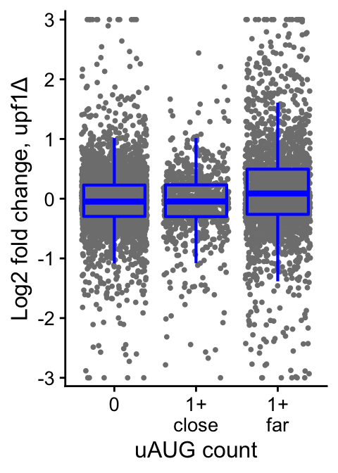

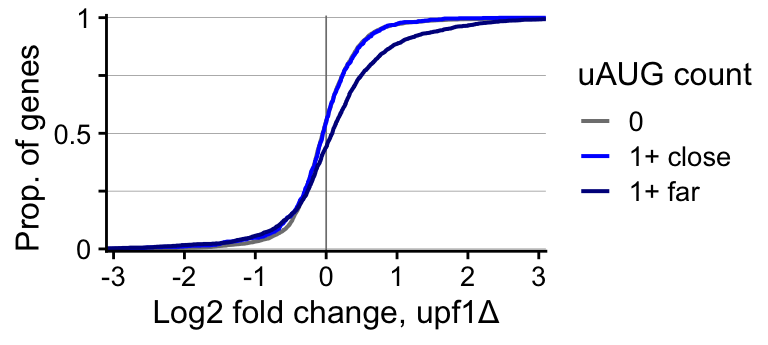

```
##
##  Two-sample Kolmogorov-Smirnov test
##
## data:  udiff %>% filter(uATGfac == "0") %>% .$log2FoldChange and udiff %>% filter(uATGfac == "1+\nclose") %>% .$log2FoldChange
## D^+ = 0.015656, p-value = 0.7294
## alternative hypothesis: the CDF of x lies above that of y
```

```
##
##  Two-sample Kolmogorov-Smirnov test
##
## data:  udiff %>% filter(uATGfac == "0") %>% .$log2FoldChange and udiff %>% filter(uATGfac == "1+\nfar") %>% .$log2FoldChange
## D^+ = 0.15596, p-value < 2.2e-16
## alternative hypothesis: the CDF of x lies above that of y
```

## Fold Change vs uATG count and score

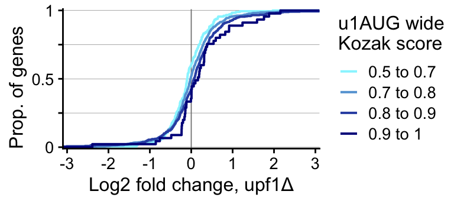

```
##
##  Two-sample Kolmogorov-Smirnov test
##
## data:  udiffsc1 %>% filter(u1.scorekw < 0.7) %>% .$log2FoldChange and udiffsc1 %>% filter(u1.scorekw > 0.9) %>% .$log2FoldChange
## D^+ = 0.25995, p-value = 0.008063
## alternative hypothesis: the CDF of x lies above that of y
```

```
##
##  Two-sample Kolmogorov-Smirnov test
##
## data:  udiffsc1 %>% filter(u1.scorekw < 0.8) %>% .$log2FoldChange and udiffsc1 %>% filter(u1.scorekw > 0.8) %>% .$log2FoldChange
## D^+ = 0.11967, p-value = 0.0001119
## alternative hypothesis: the CDF of x lies above that of y
```

# Composite figure

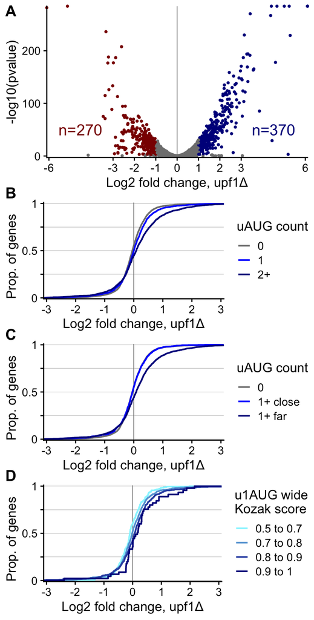